# R Notebook

Bagel2 was used to analyse reads. BF value is a indicator of gene essentiality combined with significance. a higher BF value shows a higher depletion in screen.

```r
setwd("E:/Paper writing/CRIPSRi paper/Analyses/Dolcetto_screen_analyses/publication/publication_final")
library(tidyverse)
library(ggsci)
library(reshape2)
```

```r
library(ineq)
library(ggpubr)
library(cowplot)
library(ggrepel)
library(svglite)
```

```r
theme_su<-  function(){
  font <- "Arial"   #assign font family up front

  theme_bw() %+replace%    #replace elements we want to change

    theme(


      #text elements
      plot.title = element_text(             #title
        family = "Arial",            #set font family
        size = 8,                #set font size
        face = 'bold',            #bold typeface
        hjust = 0,                #left align
        vjust = 3),               #raise slightly

      plot.subtitle = element_text(          #subtitle
        family = "Arial",            #font family
        size = 6),               #font size

      plot.caption = element_text(           #caption
        family = "Arial",            #font family
        size = 6,                 #font size
        hjust = 1),               #right align

      axis.title = element_text(             #axis titles
        family = "Arial",

        size = 6),               #font size

      axis.text = element_text(              #axis text
        family = "Arial",            #axis famuly
        size = 6),                #font size

      axis.text.x = element_text(            #margin for axis text
        margin=margin(5, b = 10)),

     legend.title=element_text(
       family="Arial",
       size=8,
       hjust = 0),
     legend.text=element_text(
       family = "Arial",
       size=6),

     panel.grid.major = element_blank(),
     panel.grid.minor = element_blank()
     )



}
```

### import gene level Bagel results for all screens

```r
all_Bagel <- read.csv("input/all_Bagel_curated.txt",sep=",")
```

##comparing monoclonal and polyclonal lines

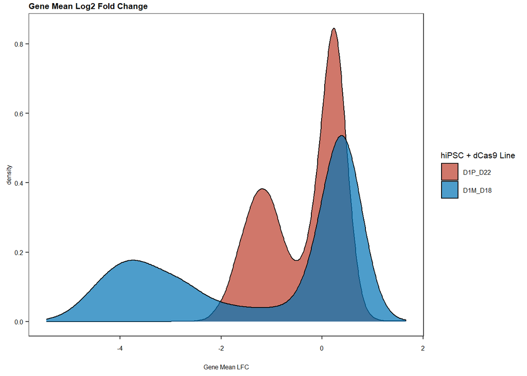

```r
mono_vs_poly_bagel<- all_Bagel %>% select(Gene, func, IPSC_polyclonal= D1P_D22, IPSC_monoclonal=D1M_D18)

all_dolcetto_LFC_Gene<- read.csv( file="output/all_dolcetto_curated_LFC.txt")

LFC_density<-all_dolcetto_LFC_Gene %>% select(func, D1P_D22, D1M_D18)%>% filter(func %in% c("CEG", "NEG")) %>% melt()  %>% ggplot(aes(x=value, fill=variable), color="black")+geom_density(alpha=0.7)+
theme_su()+scale_fill_nejm(name="hiPSC + dCas9 Line",
                                                                          labels=c("IPSC_Poly_D18"="Polyclonal" , "IPSC_D18"="Monoclonal"))+
 xlab("Gene Mean LFC")+ ggtitle("Gene Mean Log2 Fold Change")+ scale_linetype(name="Screen")
LFC_density
```

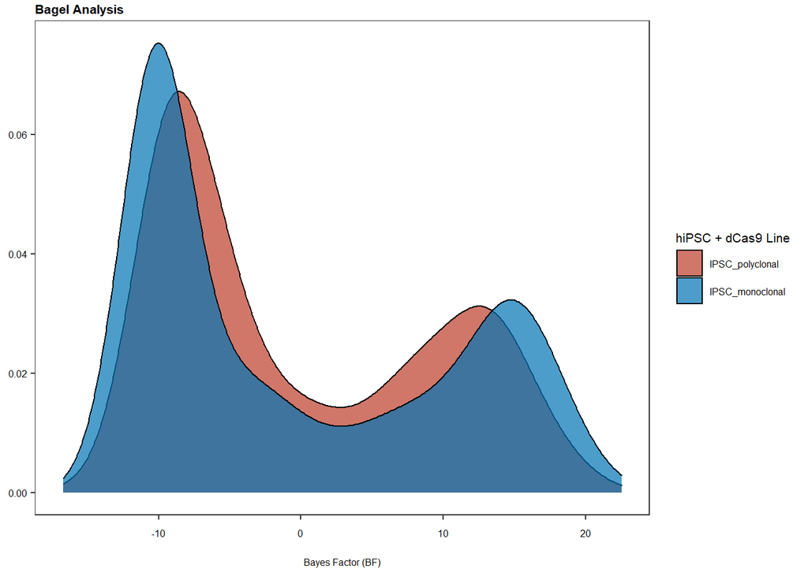

```r
BF_density<-
mono_vs_poly_bagel %>% filter(func %in% c("CEG", "NEG")) %>% melt(id=c("Gene", "func")) %>%
ggplot(aes(x=value,  fill=variable))+geom_density(color="black", alpha=0.7)+ theme_su()+scale_fill_nejm(name="hiPSC + dCas9 Line",
                                                                          labels=c("IPSC_Poly_D18"="Polyclonal" , "IPSC_D18"="Monoclonal"))+ ggtitle("Bagel Analysis")+xlab("Bayes Factor (BF)")+theme(axis.title.y = element_blank())
BF_density
```

```r
fig_3_f<-ggarrange(LFC_density, BF_density,nrow=1, common.legend = T, legend = "bottom" )
```

[output not shown]

[output cut: 28 more lines]

[output not shown]

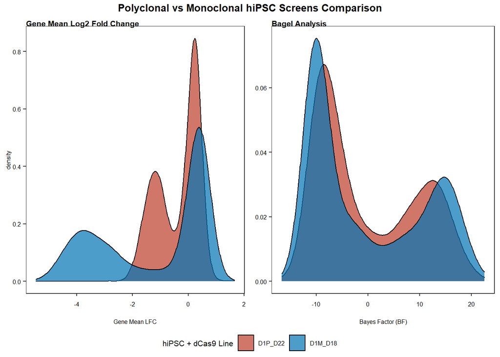

```r
fig_3_f<- annotate_figure(fig_3_f, top = text_grob("Polyclonal vs Monoclonal hiPSC Screens Comparison",
               face = "bold", size = 10))
fig_3_f
```

```r
ggsave(fig_3_f, filename= "E:/Paper writing/CRIPSRi paper/Analyses/plots/panel_3/fig_3_f.svg", height = 3, width = 4,units="in", dpi=1000)
```

polyclonal and monoclonal lines shows different depletion pattern in gene mean log2 fold change but Bagel analysis normalizes the screens with different dynamics

```r
a<- mono_vs_poly_bagel %>% filter(IPSC_polyclonal>6) %>% select(Gene)
b<- mono_vs_poly_bagel %>% filter(IPSC_monoclonal>6) %>% select(Gene)

print(paste("# of genes common between two screens",length(intersect(a$Gene, b$Gene))))
```

```
## [1] "# of genes common between two screens 1747"
```

```r
print(paste("ratio of common genes over all genes is",round((length(intersect(a$Gene, b$Gene))/length(union(a$Gene, b$Gene))),2)))
```

```
## [1] "ratio of common genes over all genes is 0.75"
```

### nocodazole test comparison:

```r
Noc_test<- all_Bagel %>% select(Gene, func, D2_Noc=D2M1R02_Noc, D2_Cont=D2M1R02_Cont)
names(Noc_test)
```

```
## [1] "Gene"    "func"    "D2_Noc"  "D2_Cont"
```

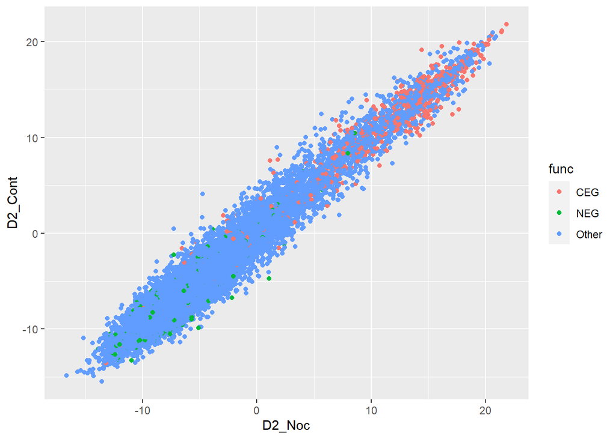

```r
Noc_test %>% ggplot(aes(x=D2_Noc, y=D2_Cont, color=func))+geom_point()
```

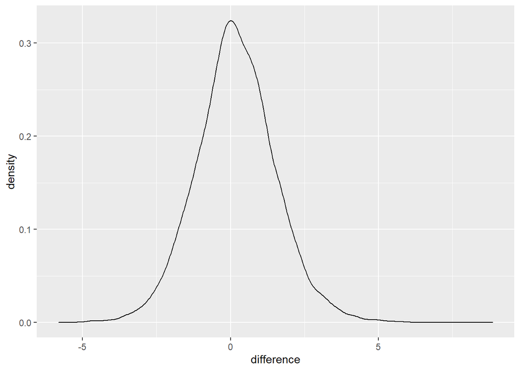

```r
Noc_test$difference<- Noc_test$D2_Cont - Noc_test$D2_Noc
Noc_test$Z_score<-scale(Noc_test$difference)
Noc_test %>% ggplot(aes(x=difference))+geom_density()
```

```r
Noc_test_melted<- melt(Noc_test)
```

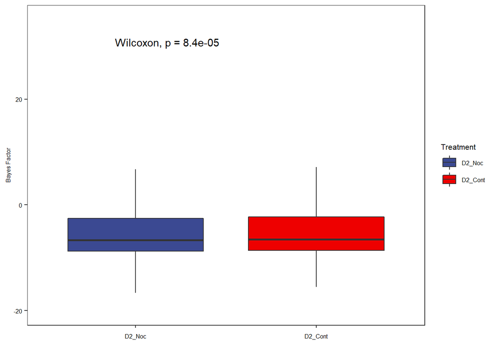

```r
supp_fig_3_i<-Noc_test_melted %>% filter(variable %in% c("D2_Noc", "D2_Cont")) %>% ggplot(aes(y=value, x=variable, fill=variable))+ geom_boxplot(outlier.shape = NA)+stat_compare_means(label.y =30)+scale_fill_aaas(name="Treatment")+ ylim(-20, 35)+theme_su()+ theme(axis.title.x =element_blank())+ ylab("Bayes Factor")
supp_fig_3_i
```

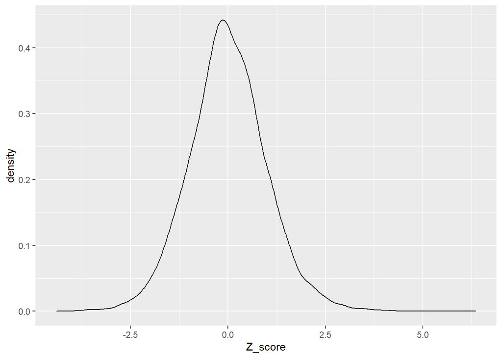

```r
ggsave(supp_fig_3_i, filename= "E:/Paper writing/CRIPSRi paper/Analyses/plots/panel_5/supp_fig_5_i.svg", height = 3, width = 4,units="in", dpi=1000)



Noc_test %>% ggplot(aes(x=Z_score))+geom_density()
```

```r
## genes with treatment and control difference outside of 99% CI (Z score > 2.576 or Z score -2.576) are labeled as enriched and depleted respectively.

Noc_test<- Noc_test %>%  mutate(group="Normal") %>% mutate(group=case_when(
  Z_score > 2.576 ~ "Enriched",
  Z_score < -2.576 ~ "Depleted",
  TRUE ~as.character(group)
))
Noc_test<- do.call(data.frame, Noc_test)
summary(Noc_test$group)
```

```
## Depleted Enriched   Normal
##      116      180    18575
```

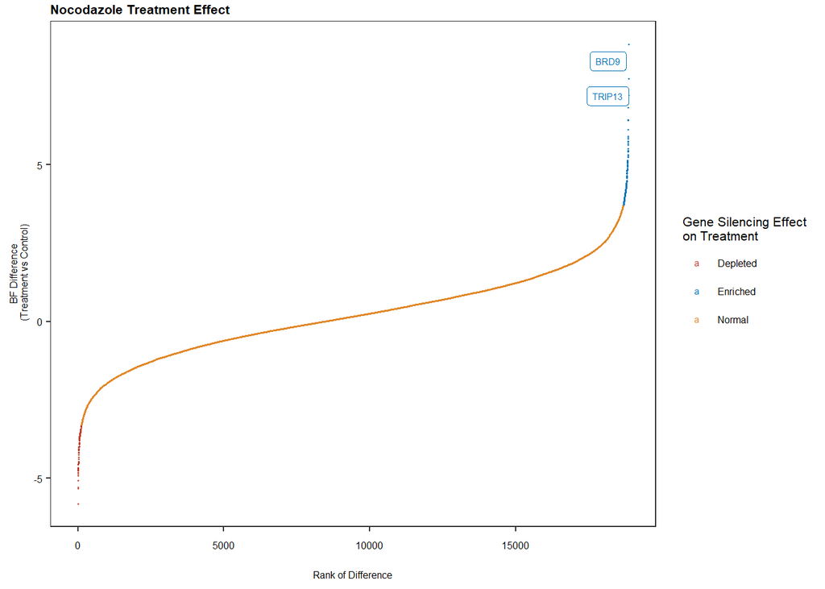

```r
Noc_test$rank<- rank(Noc_test$difference)

fig_5_a<-Noc_test%>% ggplot(aes(x=rank, y=difference, color=group))+geom_point(size=0.2)+ geom_label_repel(data=(Noc_test %>% filter(rank >18869)),aes(x=rank, y=difference,label=Gene), size=2)+theme_su()+scale_color_nejm(name="Gene Silencing Effect\non Treatment")+ylab("BF Difference\n (Treatment vs Control)")+ xlab("Rank of Difference")+ ggtitle("Nocodazole Treatment Effect")
fig_5_a
```

```r
ggsave(fig_5_a, filename= "E:/Paper writing/CRIPSRi paper/Analyses/plots/panel_5/fig_5_a_new.svg", height = 2, width = 3.5, units = "in", dpi=1000)
```

### similar approach is used to identify genes differentially essential in ARID1A mutant background

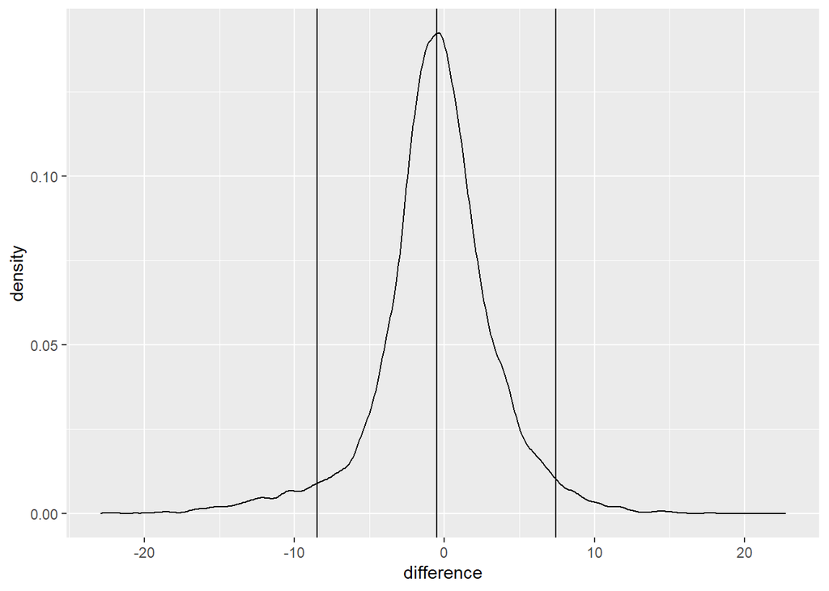

```r
DDD_bagel<- all_Bagel %>% select(Gene, func, WT_1=D2M1_All_D21, WT_2=D2M2_All_D18, Mutant=ARID1A_HT_All_D18)
DDD_bagel$WT_av<- (DDD_bagel$WT_1 + DDD_bagel$WT_2)/2
DDD_bagel$difference<- DDD_bagel$WT_av - DDD_bagel$Mutant
DDD_bagel %>% ggplot(aes(x=difference))+geom_density()+geom_vline(xintercept = mean(DDD_bagel$difference))+geom_vline(xintercept = (mean(DDD_bagel$difference)+2*sd(DDD_bagel$difference)))+geom_vline(xintercept = (mean(DDD_bagel$difference)-2*sd(DDD_bagel$difference)))
```

```r
DDD_melted_BF<- DDD_bagel %>% filter(func %in% c("CEG", "NEG")) %>% select(Gene, func, WT_av, Mutant) %>% melt
```

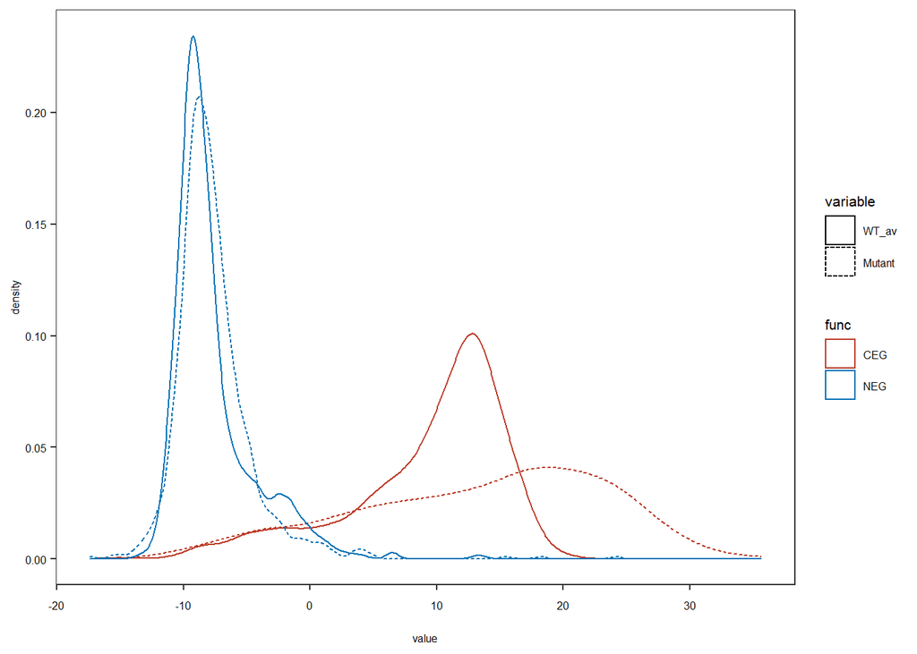

```r
supp_fig_5_a<-DDD_melted_BF %>% ggplot(aes(x=value, color= func, linetype=variable))+geom_density()+ theme_su()+scale_color_nejm()
supp_fig_5_a
```

```r
ggsave(supp_fig_5_a, filename ="E:/Paper writing/CRIPSRi paper/Analyses/plots/panel_5/supp_fig_5_a_new.svg", width =3, height=3, units = "in", dpi=1000)
```

```r
## genes with treatment and control difference outside of 2sd  are labeled as enriched and depleted respectively.

DDD_bagel<- DDD_bagel %>%  mutate(group="Normal") %>% mutate(group=case_when(
  difference > mean(difference) + 2*sd(difference) ~ "Enriched",
  difference < mean(difference) - 2*sd(difference) ~ "Depleted",
  TRUE ~as.character(group)))
table(DDD_bagel$group)
```

```
##
## Depleted Enriched   Normal
##      706      447    17718
```

[output not shown]

[output cut: 229 more lines]

[output not shown]

[output not shown]

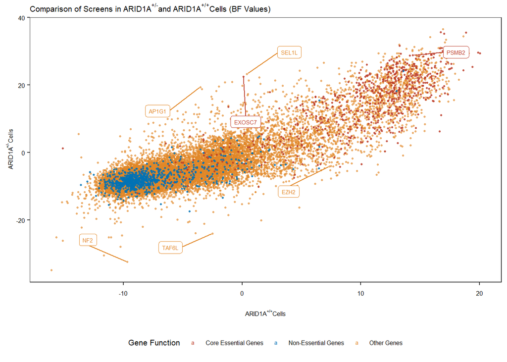

```r
scatter1<-
ggplot()+
  geom_point(data=(DDD_bagel %>% filter(func=="Other") %>% droplevels()), aes(x=WT_av, y= Mutant, color="Other"),size=0.5, alpha=0.6)+
  geom_point(data=(DDD_bagel %>% filter(func=="CEG") %>% droplevels()), aes(x=WT_av, y= Mutant, color="CEG"),size=0.5, alpha=0.8)+
  geom_point(data=(DDD_bagel %>% filter(func=="NEG") %>% droplevels()), aes(x=WT_av, y= Mutant, color="NEG"),size=0.5, alpha=0.8)+
ggtitle(expression(paste("Comparison of Screens in ARID1A" ^"+/-","and ARID1A"^"+/+", "Cells (BF Values)")))+ylab(expression(paste("ARID1A" ^"+/-","Cells")))+xlab(expression(paste("ARID1A" ^"+/+","Cells")))+theme_su()+ scale_color_nejm(name="Gene Function",labels=c("CEG"="Core Essential Genes" , "NEG"="Non-Essential Genes",  "Non-targeting_control"="Control", "Other"="Other Genes"))+theme(legend.position = "bottom")+ geom_label_repel(data=(DDD_bagel %>% filter(Gene %in% c("PSMB2", "NF2","AP1G1", "SEL1L", "EXOSC7", "TAF6L", "EZH2"))),aes(x=WT_av, y= Mutant, label=Gene, color=func), box.padding =2, size=2, max.overlaps = 10)

scatter1
```

```r
write_csv(DDD_bagel, file = "E:/Paper writing/CRIPSRi paper/Analyses/Dolcetto_screen_analyses/publication/publication_final/output/DDD_bagel_with_difference.txt")



## then add correlation data for all data together (correlation without p value)
scatter1<- scatter1+ stat_cor(data=DDD_bagel, aes(x=WT_av, y= Mutant, label = ..r.label..), inherit.aes = F, size=3)
scatter1
```

[output not shown]

[output cut: 223 more lines]

[output not shown]

[output not shown]

[figure not shown]

```r
##then produce density plots separately and add them to edges of scatter plot
xdens <- axis_canvas(scatter1, axis = "x")+
  geom_density(data = DDD_bagel, aes(x = WT_av, fill = func),
              alpha = 0.7, size = 0.2)+
 scale_fill_nejm()
ydens <- axis_canvas(scatter1, axis = "y", coord_flip = T)+
  geom_density(data = DDD_bagel, aes(x = Mutant, fill = func),
              alpha = 0.7, size = 0.2)+
 scale_fill_nejm()+coord_flip()


p1 <- insert_xaxis_grob(scatter1, xdens, grid::unit(.2, "null"), position = "top")
```

[output not shown]

[output cut: 67 more lines]

[output not shown]

[output not shown]

[output cut: 223 more lines]

[output not shown]

[output not shown]

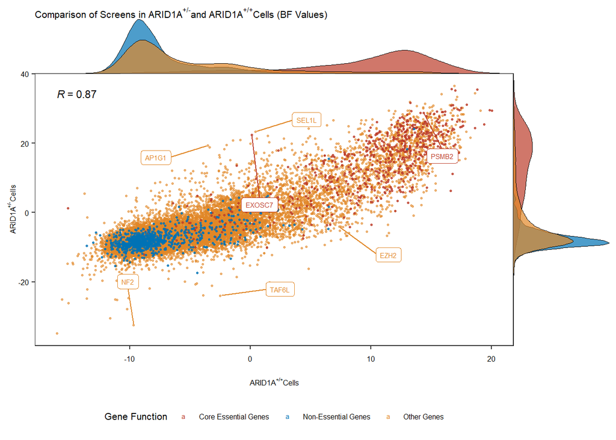

```r
p2<- insert_yaxis_grob(p1, ydens, grid::unit(.2, "null"), position = "right")
p3<- ggdraw(p2)
p3
```

```r
ggsave(p3, filename = "E:/Paper writing/CRIPSRi paper/Analyses/plots/panel_5/fig_5_b_new_new.svg", width = 2.5, height = 3, units = "in", dpi=1000)
```

### I will conduct similar analyses with gene mean LFC count

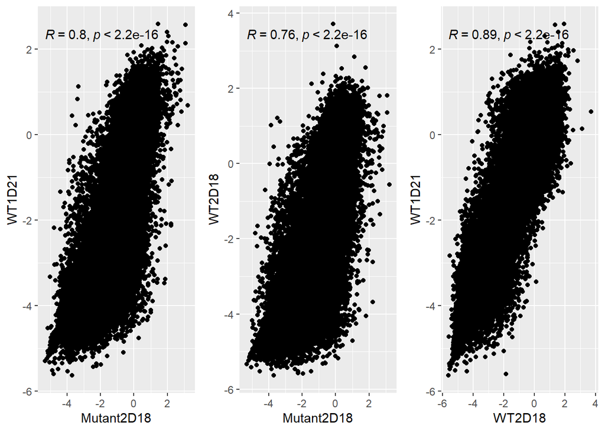

```r
##derive final timepoint all reads summed LFC data

DDD_LFC<- all_dolcetto_LFC_Gene %>% select(Gene,func, WT1D21=D2M1_All_D21, WT2D18=D2M2_All_D18, Mutant2D18=ARID1A_HT_All_D18)

p1<- DDD_LFC %>% ggplot(aes(y=WT1D21, x=Mutant2D18))+ geom_point()+stat_cor()
p2<- DDD_LFC %>% ggplot(aes(y=WT2D18, x=Mutant2D18))+ geom_point()+stat_cor()
p3<- DDD_LFC %>% ggplot(aes(y=WT1D21, x=WT2D18))+ geom_point()+stat_cor()
ggarrange(p1,p2,p3, nrow=1)
```

two wild type screens are correlated so we decided to use their mean for further analyses

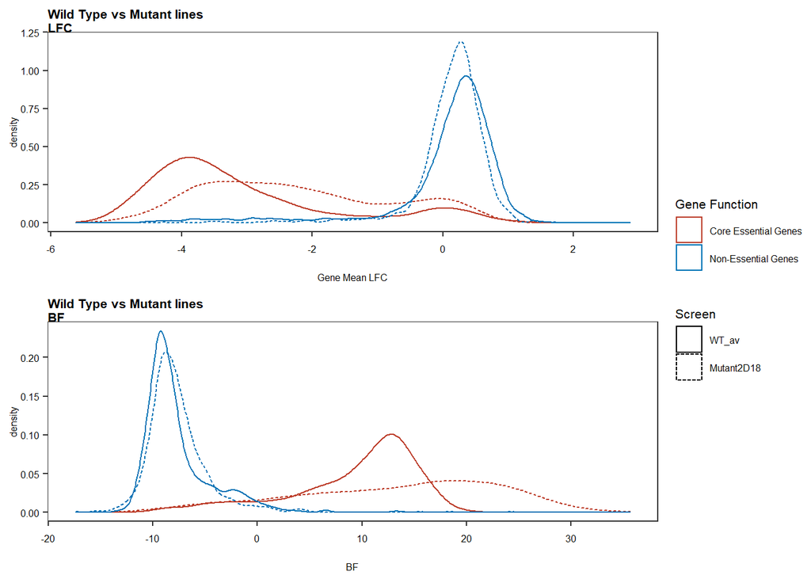

```r
DDD_LFC$WT_av<- (DDD_LFC$WT1D21 +DDD_LFC$WT2D18)/2

### lets see the density plot
melted_ddd_lfc<- DDD_LFC %>% select(Gene, func, WT_av, Mutant2D18) %>% melt()
plot3<- melted_ddd_lfc %>% filter(func %in% c("CEG","NEG")) %>%  ggplot(aes(x=value, color= func, linetype=variable))+geom_density()+ theme_su()+scale_color_nejm(name="Gene Function",
                                                                          labels=c("CEG"="Core Essential Genes" , "NEG"="Non-Essential Genes",  "Non-targeting_control"="Control", "Other"="Other Genes"))+
 xlab("Gene Mean LFC")+ ggtitle("Wild Type vs Mutant lines\nLFC")+ scale_linetype(name="Screen")


plot4<- DDD_melted_BF %>% filter(func %in% c("CEG","NEG"))%>% ggplot(aes(x=value, color= func, linetype=variable))+geom_density()+ theme_su()+scale_color_nejm(name="Gene Function",
                                                                          labels=c("CEG"="Core Essential Genes" , "NEG"="Non-Essential Genes",  "Non-targeting_control"="Control", "Other"="Other Genes"))+
 xlab("BF")+ ggtitle("Wild Type vs Mutant lines\nBF")+ scale_linetype(name="Screen")

supp_fig_5_b<- ggarrange(plot3,plot4, ncol = 1, common.legend = T, legend = "right")
supp_fig_5_b
```

```r
ggsave(supp_fig_5_b, filename= "E:/Paper writing/CRIPSRi paper/Analyses/plots/panel_5/supp_fig_5_b_new.svg", height = 4, width =4, units = "in", dpi=1000)
```

```r
DDD_LFC<- DDD_LFC %>% mutate(difference=(WT_av - Mutant2D18)) %>% mutate(scaled=scale(difference))

DDD_LFC<- DDD_LFC %>%  mutate(group="Normal") %>% mutate(group=case_when(
  difference > mean(difference) + 2*sd(difference) ~ "Depleted",
  difference < mean(difference) - 2*sd(difference) ~ "Enriched",
  TRUE ~as.character(group)))
table(DDD_LFC$group)
```

```
##
## Depleted Enriched   Normal
##      249     3367    53426
```

annotate enriched and depleted genes according to LFC

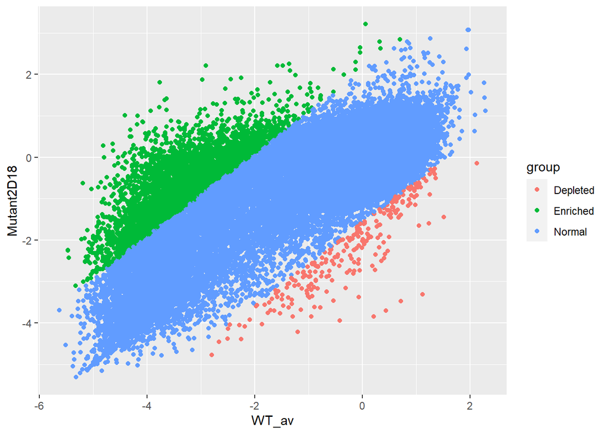

```r
DDD_LFC %>% ggplot(aes(x=WT_av,y=Mutant2D18, color=group))+
  geom_point()
```

differential essential genes are annotated differently with different analysis methods. as follow-up difference analysis will be replicated with a small pooled library

###small pooled library design

```r
bagel_selected_genes<- DDD_bagel %>% filter(group != "Normal")
lfc_seelcted_genes<- DDD_LFC %>% filter(group != "Normal")

DDD_bagel<- DDD_bagel %>% mutate(pool_group="none") %>%mutate(pool_group=case_when(
  Gene %in% bagel_selected_genes$Gene & Gene %in% lfc_seelcted_genes$Gene~ "both",
  Gene %in% bagel_selected_genes$Gene ~ "bagel",
  Gene %in% lfc_seelcted_genes$Gene~ "LFC",
  TRUE ~ as.character(pool_group)))


pool_genes<- DDD_bagel %>% filter(pool_group !="none") %>% droplevels()
```

## genes depleted or enriched by either of the methods are selected for follow-up. genes with non-specific guides and bidirectional promotes are eliminated:

a final pooled library is designed by adding 70 Non essential genes and 200 non-targeting control guides.